# ggcubeで3D地図

Kanazawa.R #6

伊東宏樹

2026-11-28

## 今回の内容

- 3D地図を描画
- アニメーションにしてぐるぐるまわす
- ggcubeパッケージを利用

## データ

国土地理院の[基盤地図情報](https://service.gsi.go.jp/kiban/)数値標高モデルを使用します（ダウンロードにはユーザー登録が必要）。

10mメッシュ (10B) の以下のファイルをダウンロードしました。

- FG-GML-5436-55-dem10b-20161001.xml
- FG-GML-5436-64-dem10b-20161001.xml
- FG-GML-5436-65-dem10b-20161001.xml
- FG-GML-5436-44-dem10b-20161001.xml
- FG-GML-5436-45-dem10b-20161001.xml
- FG-GML-5436-54-dem10b-20161001.xml

## 前処理

ダウンロードしたDEMデータを、QGISで結合してGeoTIFF出力しておきました。ファイル名は`Tedorigawa.tiff`です。

[figure not shown]

## データの読み込み

terraパッケージの`rast()`関数でGeoTIFFを読み込んで、概要を表示します。

```r
geotiff_file <- "Tedorigawa.tiff"
(dem <- terra::rast(file.path(data_dir, geotiff_file)))
```

```
class       : SpatRaster
size        : 2250, 2250, 1  (nrow, ncol, nlyr)
resolution  : 0.0001111111, 0.0001111111  (x, y)
extent      : 136.5, 136.75, 36.33333, 36.58333  (xmin, xmax, ymin, ymax)
coord. ref. : lon/lat JGD2000 (EPSG:4612)
source      : Tedorigawa.tiff
name        :  Tedorigawa
min value   :           0
max value   : 1286.900024
```

## データの処理

`aggregate()`関数で、10ピクセルごとの平均でまとめ、`as.data.frame()`関数でデータフレームに変換します。

標高の列名を`elev`にかえます。また、`elev_max`に標高の最大値（100m単位で切り上げ）を入れておきます。

```r
dem_df <- dem |>
  terra::aggregate(fact = 10, fun = "mean") |>
  terra::as.data.frame(xy = TRUE) |>
  dplyr::rename(elev = names(dem))
elev_max <- ceiling(max(dem_df$elev, na.rm = TRUE) / 100) * 100
```

## 3D描画

`geom_surface_3d()`関数で3次元プロット

```r
map_3d <- ggplot(dem_df, aes(x = x, y = y, z = elev)) +
  geom_surface_3d(aes(fill = elev)) +
  scale_fill_gradientn(
    colors = c("blue", "#336600", "#78AB46", "#C8B560",
               "#A0785A", "#8B5A2B", "#D2B48C", "#FFFFFF"),
    values  = c(0, 0.001, 0.01, 0.05, 0.1, 0.5, 0.75, 1),
    limits  = c(0, elev_max),
    name = "標高 (m)"
  ) +
  labs(x = "経度", y = "緯度", z = "標高 (m)") +
  coord_3d(pitch = 0, roll = -60, yaw = 190,
           # 標高を強調して表示, xy軸の単位は度、z軸の単位はm
           ratio = c(1, 1, 0.2)) +
  theme_minimal(base_family = jp_font, base_size = 10)
map_3d
```

## 3D描画

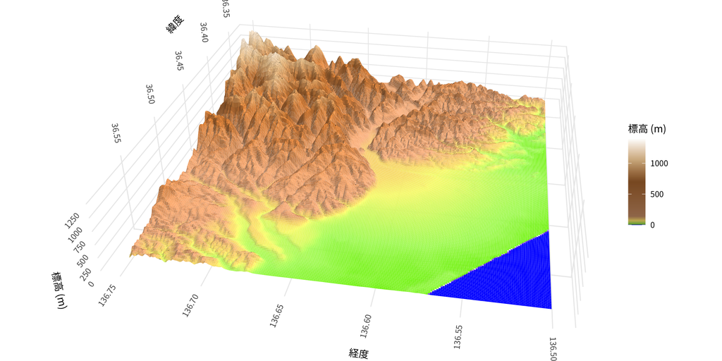

## 3Dアニメーションの作成

`animate_3d()`関数でアニメーションを作成します（時間がかかります）。

```r
anim_map <- animate_3d(map_3d,
                       yaw = c(0, 360),
                       width = 640, height = 640)
anim_save_3d(anim_map,
             file.path(output_dir, "map-animation.gif"))
```

## できあがり

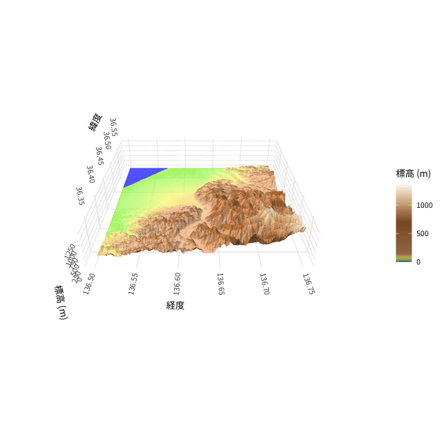